# Lab 2 · Depuración: cada decisión tiene un coste

Desaprendiendo sobre… Limpieza de datos · Estudiante_18 (sector Servicios)

> **Objetivo.** Ver cómo se resuelve cada problema que detectó la auditoría **y quién decide** qué se hace con él. Fíjate en que algunas cosas se **corrigen**, otras solo se **marcan** y otras solo se **preguntan**.

```r
# ── Preparación (ejecutar una vez) ───────────────────────────────────────────
# En Colab/Linux usamos binarios precompilados: los paquetes se instalan en segundos.
if (Sys.info()[["sysname"]] == "Linux")
  options(repos = c(CRAN = "https://packagemanager.posit.co/cran/__linux__/jammy/latest"))

paquetes <- c("tidyverse")
faltan <- paquetes[!vapply(paquetes, requireNamespace, logical(1), quietly = TRUE)]
if (length(faltan)) install.packages(faltan)
suppressPackageStartupMessages({
library(tidyverse)
})

# Los datos: si no están en la carpeta, se descargan
BASE_URL <- "https://raw.githubusercontent.com/vicentcorrecher/lab-limpieza-datos/main/datos"
obtener <- function(f) {
  ruta <- file.path("datos", f)
  if (!file.exists(ruta)) {
    dir.create(dirname(ruta), recursive = TRUE, showWarnings = FALSE)
    download.file(paste0(BASE_URL, "/", f), ruta, quiet = TRUE, mode = "wb")
  }
}
for (f in c(
  "funciones_labs.R",
  "estudiante_18/operaciones.csv",
  "estudiante_18/clientes.csv",
  "estudiante_18/productos_servicios.csv",
  "estudiante_18/sedes.csv",
  "estudiante_18/campanas.csv"
)) obtener(f)
source("datos/funciones_labs.R")
```

```r
d <- cargar_e18()
o <- d$operaciones
```

## 1. Duplicados: lo evidente

```r
dup <- o |> filter(duplicated(operacion_id) | duplicated(operacion_id, fromLast = TRUE)) |> arrange(operacion_id)
dup |> select(operacion_id, fecha, cliente_id, canal, ingresos, satisfaccion) |> head(8)
```

```
# A tibble: 8 × 6
  operacion_id fecha      cliente_id canal    ingresos satisfaccion
  <chr>        <date>     <chr>      <chr>       <dbl>        <dbl>
1 O0001008     2024-01-17 C00402     app         127.             7
2 O0001008     2024-01-17 C00402     app         127.             7
3 O0001312     2023-07-27 C00225     web          89.4            8
4 O0001312     2023-07-27 C00225     web          89.4            8
5 O0003159     2022-10-22 C01977     telefono     17.9           10
6 O0003159     2022-10-22 C01977     telefono     17.9           10
7 O0006430     2024-10-13 C00559     telefono    314.             8
8 O0006430     2024-10-13 C00559     telefono    314.             8
```

```r
cat("Filas duplicadas:", nrow(o) - nrow(distinct(o)), "\n")
```

```
Filas duplicadas: 8
```

```r
cat("Ingresos que se contarían de más:", round(sum(o$ingresos) - sum(distinct(o)$ingresos), 2), "€\n")
```

```
Ingresos que se contarían de más: 1071.2 €
```

**Decisión: eliminar.** Es la misma fila entera dos veces; no hay duda razonable.

## 2. Categorías: lo que se arregla con una regla

```r
d$clientes |> count(canal_alta, sort = TRUE)
```

```
# A tibble: 5 × 2
  canal_alta     n
  <chr>      <int>
1 presencial   904
2 web          880
3 app          602
4 referido     261
5 Web           27
```

```r
d$clientes |> mutate(canal_alta = str_to_lower(str_squish(canal_alta))) |> count(canal_alta, sort = TRUE)
```

```
# A tibble: 4 × 2
  canal_alta     n
  <chr>      <int>
1 web          907
2 presencial   904
3 app          602
4 referido     261
```

**Decisión: normalizar** (minúsculas, sin espacios sobrantes). Ojo: esto solo sirve porque *sabemos* que «Web » y «web» son lo mismo.

## 3. Operaciones anteriores al alta del cliente: un problema que no es del dato

```r
oc <- o |>
  left_join(select(d$clientes, cliente_id, fecha_alta), by = "cliente_id") |>
  mutate(dias_antes = as.numeric(fecha_alta - fecha))

oc |>
  group_by(anyo_de_alta = year(fecha_alta)) |>
  summarise(operaciones = n(), anteriores_al_alta = sum(dias_antes > 0), pct = round(100 * mean(dias_antes > 0), 1))
```

```
# A tibble: 5 × 4
  anyo_de_alta operaciones anteriores_al_alta   pct
         <dbl>       <int>              <int> <dbl>
1         2019        3750                  0   0
2         2020        3741                  0   0
3         2021        3584                  0   0
4         2022        3953                481  12.2
5         2023        3980               1479  37.2
```

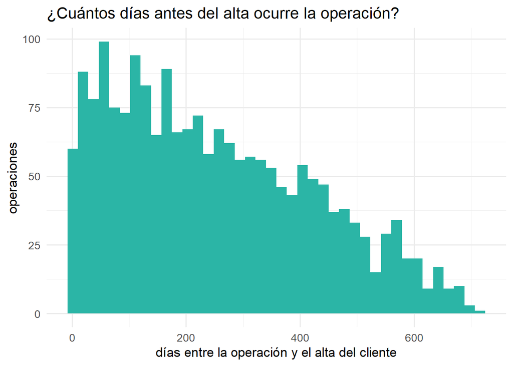

```r
oc |> filter(dias_antes > 0) |>
  ggplot(aes(dias_antes)) +
  geom_histogram(bins = 40, fill = "#2BB5A6") +
  labs(title = "¿Cuántos días antes del alta ocurre la operación?", x = "días entre la operación y el alta del cliente", y = "operaciones") +
  theme_minimal(base_size = 13)
```

Solo afecta a clientes dados de alta en 2022-2023, justo cuando empieza el periodo de operaciones. Hipótesis posibles:

1. `fecha_alta` es la fecha de registro en el CRM, no la de su primera compra (clientes migrados).
2. Error al introducir el alta.
3. Las operaciones se imputan a clientes que luego se registran (venta sin registro).

**Decisión: marcar, no borrar.** Con los datos no podemos distinguir entre estas hipótesis; hay que preguntarlo a quien conoce el proceso.

## 4. Margen negativo: ¿error o decisión comercial?

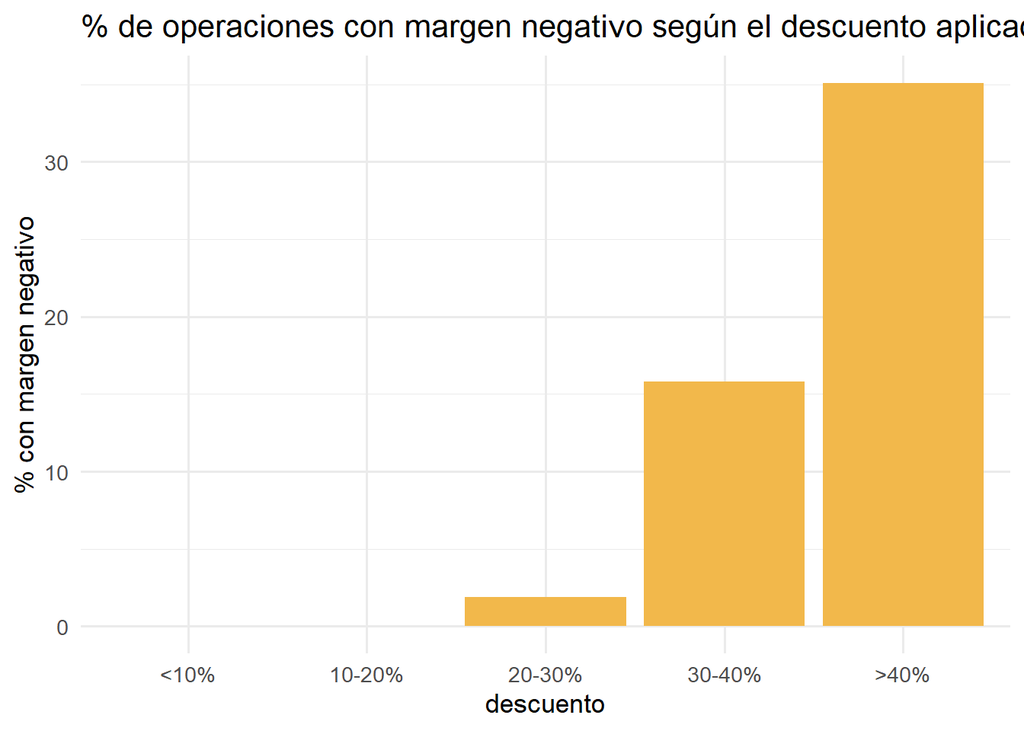

```r
o |>
  mutate(tramo_dto = cut(descuento_pct, c(-Inf, .1, .2, .3, .4, Inf), labels = c("<10%", "10-20%", "20-30%", "30-40%", ">40%"))) |>
  group_by(tramo_dto) |>
  summarise(operaciones = n(), pct_con_margen_negativo = round(100 * mean(margen < 0), 1)) |>
  ggplot(aes(tramo_dto, pct_con_margen_negativo)) +
  geom_col(fill = "#F2B84B") +
  labs(title = "% de operaciones con margen negativo según el descuento aplicado", x = "descuento", y = "% con margen negativo") +
  theme_minimal(base_size = 13)
```

El margen negativo **solo aparece con descuentos altos**. Eso no huele a error de tecleo: huele a política de descuentos.

**Decisión: marcar y avisar a negocio.** Eliminarlas escondería justo lo que a dirección le interesa ver.

## 5. Valores extremos en `duracion_min` (variable propia del sector Servicios)

```r
lim_iqr <- \(x, k) quantile(x, .75) + k * IQR(x)

o |> left_join(d$productos |> select(producto_id, categoria), by = "producto_id") |>
  group_by(categoria) |>
  summarise(mediana = median(duracion_min), p99 = quantile(duracion_min, .99), maximo = max(duracion_min),
            atipicas_k15 = sum(duracion_min > lim_iqr(duracion_min, 1.5)),
            atipicas_k3  = sum(duracion_min > lim_iqr(duracion_min, 3)),
            atipicas_k5  = sum(duracion_min > lim_iqr(duracion_min, 5)))
```

```
# A tibble: 4 × 7
  categoria     mediana   p99 maximo atipicas_k15 atipicas_k3 atipicas_k5
  <chr>           <dbl> <dbl>  <dbl>        <int>       <int>       <int>
1 asistencia         60  177.    312          132          24           1
2 consultoria        60  178     459          243          44           7
3 mantenimiento      60  170     289          145          20           2
4 reparacion         60  172     320          165          27           4
```

La regla «Q3 + k·IQR» marca como atípico lo que se aleja del grueso. **El umbral `k` lo elige quien analiza**: con 1,5 marca muchos valores; con 5, casi ninguno.

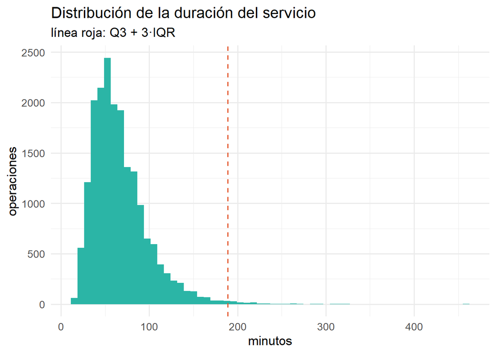

```r
o |> ggplot(aes(duracion_min)) +
  geom_histogram(bins = 60, fill = "#2BB5A6") +
  geom_vline(xintercept = quantile(o$duracion_min, .75) + 3 * IQR(o$duracion_min), colour = "#E4572E", linetype = "dashed") +
  labs(title = "Distribución de la duración del servicio", subtitle = "línea roja: Q3 + 3·IQR", x = "minutos", y = "operaciones") +
  theme_minimal(base_size = 13)
```

**Decisión: marcar.** Un servicio de 7 horas puede ser un error o un proyecto grande.

## 6. Lo que has visto, en una sola función

Toda la limpieza anterior vive en `limpiar_e18()` (puedes abrir `datos/funciones_labs.R` y leerla). Cada decisión es un **argumento**: por defecto **solo se marcan** los problemas y se eliminan los duplicados exactos.

```r
# >>> TOCA AQUÍ: elige qué problemas se convierten en filas eliminadas <<<
# opciones: "antes_alta", "antes_lanzamiento", "margen_negativo", "sector"
EXCLUIR <- c()          # prueba, por ejemplo: c("antes_alta")   o   c("margen_negativo", "sector")
K_IQR   <- 3            # prueba 1.5 o 5

l <- limpiar_e18(d, excluir = EXCLUIR, k_iqr = K_IQR)
l$log
```

```
# A tibble: 7 × 3
  regla                                           filas_afectadas decision
  <chr>                                                     <int> <chr>
1 canal_alta con mayúsculas/espacios                           27 normalizar (m…
2 filas duplicadas (operacion_id repetido)                      8 eliminar
3 operación anterior al alta del cliente                     1958 marcar
4 operación anterior al lanzamiento del producto             1346 marcar
5 margen negativo (coste > ingresos)                          186 marcar
6 duracion_min atípica (Q3 + 3·IQR por categoría)             113 marcar
7 exclusión elegida: ninguna                                    0 eliminar de l…
```

```r
cat("Filas de operaciones: ", nrow(d$operaciones), "(originales) ->", nrow(l$operaciones), "(tras tus decisiones)\n")
```

```
Filas de operaciones:  19008 (originales) -> 19000 (tras tus decisiones)
```

### Para pensar

> 1. De los cinco problemas, ¿cuáles **corriges**, cuáles **marcas** y cuáles **preguntas**? ¿Qué criterio has usado?
> 2. Excluye `"antes_alta"` y mira cuántas filas desaparecen. ¿Te parece razonable descartar tanto dato por una fecha de alta?
> 3. Hay 1.346 operaciones anteriores al **lanzamiento del servicio** (`"antes_lanzamiento"`). ¿Qué dato está mal, la operación o la fecha de lanzamiento?
> 4. El «diario» (`l$log`) lista las decisiones. ¿Por qué es importante que **quede escrito** y no solo hecho?